# Model building and expansion example: Golf putting

## Input data

Data from professional golfers on the proportion of successful putts as a function of distance from the hole:

- $x$ is the distance from the hole (feet)
- $n$ is the number of attemps
- $y$ is the number of successful shots made
- $p = \frac{y}{n}$ is the probability of success

```
## # A tibble: 19 x 4
##        x     n     y     p
##    <dbl> <dbl> <dbl> <dbl>
##  1     2  1443  1346 0.933
##  2     3   694   577 0.831
##  3     4   455   337 0.741
##  4     5   353   208 0.589
##  5     6   272   149 0.548
##  6     7   256   136 0.531
##  7     8   240   111 0.462
##  8     9   217    69 0.318
##  9    10   200    67 0.335
## 10    11   237    75 0.316
## 11    12   202    52 0.257
## 12    13   192    46 0.240
## 13    14   174    54 0.310
## 14    15   167    28 0.168
## 15    16   201    27 0.134
## 16    17   195    31 0.159
## 17    18   191    33 0.173
## 18    19   147    20 0.136
## 19    20   152    24 0.158
```

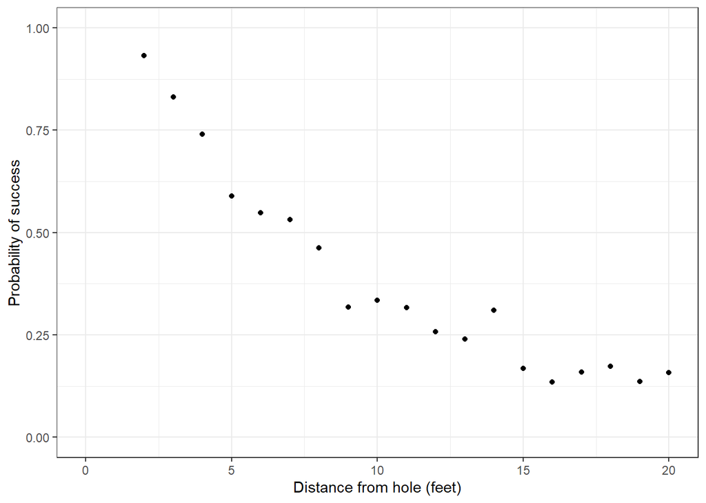

## First model: Logistic regression

with stan model:

```stan
// J observations of n (trials), y (successes) for each distance value x
data {
  int<lower=0> J;
  int n[J];
  int y[J];
  vector[J] x;
}

// Parametrised by a and b
parameters {
  real a;
  real b;
}

model {
  vector[J] p;

  for (j in 1:J) {
    p[j] = inv_logit(a + b*x[j]);
  }

  y ~ binomial(n, p);
}

generated quantities {
  vector[J] y_rep;
  vector[J] p;

  for (j in 1:J) {
    p[j] = inv_logit(a + b*x[j]);
    y_rep[j] = binomial_rng(n[j], p[j]);
  }
}
```

where uniform priors are used due to the high number of trials for each $n_j$.

We can posterior

```
## # A tibble: 1 x 2
##       a      b
##   <dbl>  <dbl>
## 1  2.23 -0.256
```

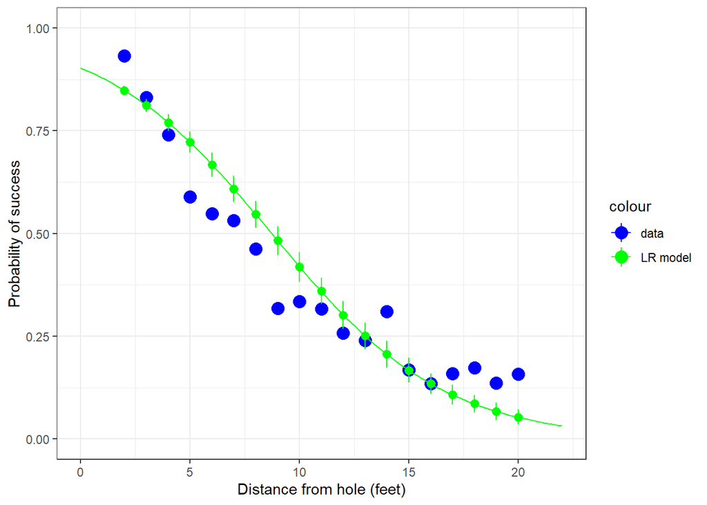

## Second model: Considering geometry

The figure below shows a simplified sketch of a golf shot:

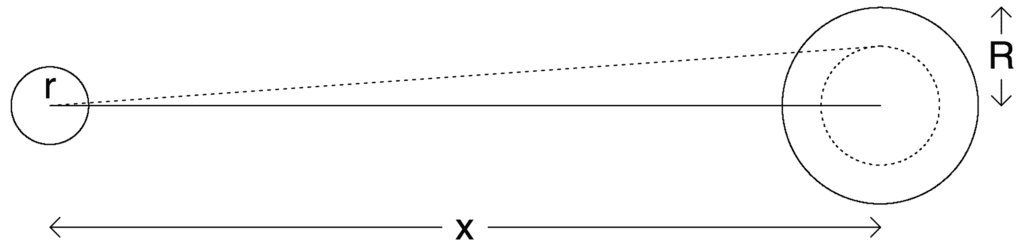

Simple geometrical model of golf putting.

The dotted lines represent the (maximum) angle which the ball of radius $r$ must be hit so that it falls within the hole of radius $R$, being hit from a distance of $x$ feet. This maximum angle is:

$$\text{sin}^{-1} \Bigg( \frac{R - r}{x} \Bigg)$$

We assume that the golfer attempts to hit the ball straight but that many small factors interfere with this goal. Hence, we assume the actual angle $k$ follows a normal distribution centered at 0 with some standard deviation $\sigma$.

The probability that the ball goes inside the all is equal to the probability that the angle is below the maximum threshold, that is,

$$\text{Pr} \Big( k < \text{sin}^{-1} \big((R - r)/x \big) \Big) = 2 \Phi \Bigg( \frac{\text{sin}^{-1} \big((R - r)/x \big)}{\sigma} \Bigg) - 1$$
transforming the original model into:

$$y_j \sim \text{binomial} (n_j , p_j), \ \text{for} \ j = 1, \ldots, J \\
p_j = 2 \Phi \Bigg( \frac{\text{sin}^{-1} \big((R - r)/x \big)}{\sigma} \Bigg) - 1$$

with stan model:

```stan
// J observations of n (trials), y (successes) for each distance value x
data {
  int<lower=0> J;
  int n[J];
  int y[J];
  vector[J] x;
  real r;
  real R;
}

// Parametrised by a and b
parameters {
  real sigma;
}

model {
  vector[J] p;

  for (j in 1:J) {
    p[j] = 2*Phi(asin((R-r)/x[j]) / sigma) - 1;
  }

  y ~ binomial(n, p);
}

generated quantities {
  real sigma_degrees;
  vector[J] y_rep;
  vector[J] p;

  sigma_degrees = (180/pi())*sigma;

  for (j in 1:J) {
    p[j] = 2*Phi(asin((R-r)/x[j])/sigma) - 1;
    y_rep[j] = binomial_rng(n[j], p[j]);
  }
}
```

```r
r_feet <- 1.68/2 * 0.0833 # inches to feet
R_feet <- 4.25/2 * 0.0833 # inches to feet

fit2 <- stan(
  model_code = model2,
  chains = 4,
  iter = 2000,
  data = list(
    J = nrow(golf), x = golf$x, y = golf$y, n = golf$n, r = r_feet, R = R_feet
  )
)
```

We can posterior

```
## # A tibble: 1 x 2
##    sigma sigma_degrees
##    <dbl>         <dbl>
## 1 0.0266          1.53
```

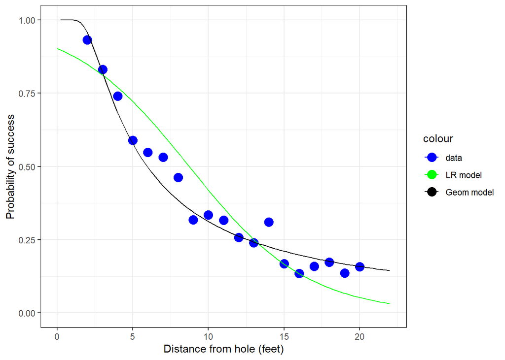

### New golf data

```
## # A tibble: 31 x 3
##        x      n      y
##    <dbl>  <dbl>  <dbl>
##  1  0.28  45198  45183
##  2  0.97 183020 182899
##  3  1.93 169503 168594
##  4  2.92 113094 108953
##  5  3.93  73855  64740
##  6  4.94  53659  41106
##  7  5.94  42991  28205
##  8  6.95  37050  21334
##  9  7.95  33275  16615
## 10  8.95  30836  13503
## 11  9.95  28637  11060
## 12 11.0   26239   9032
```

[output cut: 19 more lines]

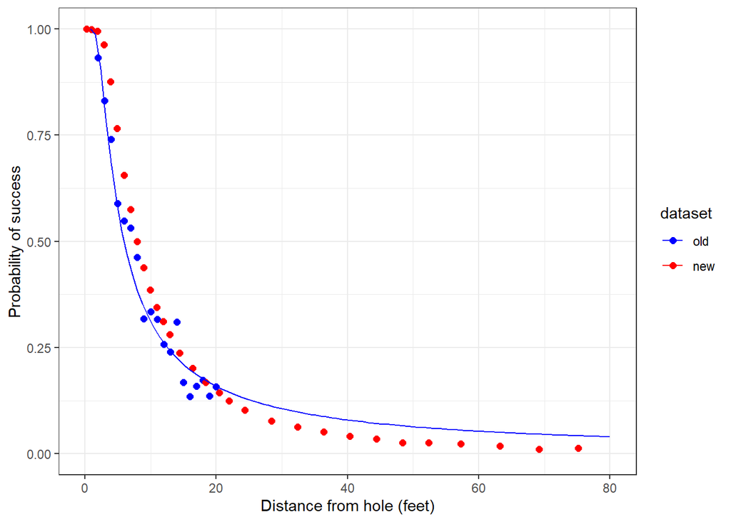